# MSDS 6306 Case Study Two

Ryan Herrin

11/19/2021

# Setup and read-in provided Data

```r
# define locations within folder structure
comp_set_loc <- "./StartingDBs/CaseStudy2-data.csv"
comp_set_no_attrition_loc <- "./StartingDBs/CaseStudy2CompSet-No-Attrition.csv"
comp_set_no_salary_loc <- "./StartingDBs/CaseStudy2CompSet-No-Salary.xlsx"

# Read-in data and create dataframes
comp_set <- read.csv(comp_set_loc, header = TRUE)
comp_set_no_attrition <- read.csv(comp_set_no_attrition_loc, header = TRUE)
comp_set_no_salary <- read.xlsx(file=comp_set_no_salary_loc, sheetIndex = 1,
                                header=TRUE, stringsAsFactors = FALSE)
```

# Reusable Functions

```r
# Create normalization function for continouse varibales
min_max_norm <- function(x) {(x - min(x)) / (max(x) - min(x))}

CategoryToPercent <- function(df) {
  # Function that will transform each catigorical value into percentages based on its relation to attrition
  # Uses the WOE method. **** Attrition Must be First Column ****
  df <- df

  for(col in 2:ncol(df)) {
    tmp_count <- count(df[col])
    colnames(tmp_count) <- c("x", "freq") # rename columns to make them standard

    for(val in 1:length(tmp_count$x)) {
      # Get number of rows that have the val with a Yes for attrition
      count_attrition <- nrow(filter(df, df[1]=="Yes" & df[col]==tmp_count$x[val]))
      # Calculate percentage
      #percent_attrtion <- (count_attrition / tmp_count$freq[val])
      percent_attrtion <- (count_attrition / sum(tmp_count$freq))
      # Now lets make the change to the data to replace the data frame
      df[col] <- replace(df[col], df[col]==tmp_count$x[val], percent_attrtion)
    }
  }
  return(df)
}

InvertPercentage <- function(x) {
  # Invert percentage to standardize relationship between cat and cont dataframes
  res <- (1 - x)
  return(res)
}

PrepareData <- function(df) {
  # Function to apply the same normaliztion methods to data that has attrition and
  # for the data that does not have attrition
  df_pd <- df
  # Remove data that provides no statistical value
  df_pd <- subset(df_pd, select=-c(EmployeeCount, EmployeeNumber, Over18, StandardHours))
  # Removing additional data due to correlation data
  df_pd <- subset(df_pd, select=-c(HourlyRate, MonthlyRate, PercentSalaryHike, Education,
                                   PerformanceRating, RelationshipSatisfaction))
  # Transform all Numeric Categoires as.numeric()
  # Transform all Categorical data that has a number as.factor()
  df_pd <- transform(df_pd,
                     Age=as.numeric(Age),
                     BusinessTravel=as.factor(BusinessTravel), DailyRate=as.numeric(DailyRate),
                     Department=as.factor(Department), DistanceFromHome=as.numeric(DistanceFromHome),
                     EducationField=as.factor(EducationField),
                     EnvironmentSatisfaction=as.factor(EnvironmentSatisfaction),
                     Gender=as.factor(Gender), JobInvolvement=as.factor(JobInvolvement),
                     JobLevel=as.factor(JobLevel), JobRole=as.factor(JobRole),
                     JobSatisfaction=as.factor(JobSatisfaction),
                     MaritalStatus=as.factor(MaritalStatus),
                     MonthlyIncome=as.numeric(MonthlyIncome),
                     NumCompaniesWorked=as.numeric(NumCompaniesWorked),
                     OverTime=as.factor(OverTime), StockOptionLevel=as.factor(StockOptionLevel),
                     TotalWorkingYears=as.numeric(TotalWorkingYears),
                     TrainingTimesLastYear=as.numeric(TrainingTimesLastYear),
                     WorkLifeBalance=as.factor(WorkLifeBalance),
                     YearsAtCompany=as.numeric(YearsAtCompany),
                     YearsInCurrentRole=as.numeric(YearsInCurrentRole),
                     YearsSinceLastPromotion=as.numeric(YearsSinceLastPromotion),
                     YearsWithCurrManager=as.numeric(YearsWithCurrManager)
                     )

  # In case the data does not have the "Attrition" Column
  if("Attrition" %in% names(df_pd)) {
    df_pd <- transform(df_pd, Attrition=as.factor(Attrition))
  }

  return(df_pd)
}

ConvertCatToNum <- function(df) {
  # Convert Categorical Variables to numerical, but as.factor()
  df_cctm <- df
  # Attrition
    # In case the data does not have the "Attrition" Column
  if("Attrition" %in% names(df_cctm)) {
    df_cctm$Attrition[df_cctm$Attrition=="No"] <- 0
    df_cctm$Attrition[df_cctm$Attrition=="Yes"] <- 1
  }
  # Business Travel
  df_cctm$BusinessTravel[df_cctm$BusinessTravel=="Non-Travel"] <- 1
  df_cctm$BusinessTravel[df_cctm$BusinessTravel=="Travel_Rarely"] <- 2
  df_cctm$BusinessTravel[df_cctm$BusinessTravel=="Travel_Frequently"] <- 3
  # Employee Dept
  df_cctm$Department[df_cctm$Department=="Human Resources"] <- 1
  df_cctm$Department[df_cctm$Department=="Research & Development"] <- 2
  df_cctm$Department[df_cctm$Department=="Sales"] <- 3
  # Education Field
  df_cctm$EducationField[df_cctm$EducationField=="Human Resources"] <- 1
  df_cctm$EducationField[df_cctm$EducationField=="Life Sciences"] <- 2
  df_cctm$EducationField[df_cctm$EducationField=="Marketing"] <- 3
  df_cctm$EducationField[df_cctm$EducationField=="Medical"] <- 4
  df_cctm$EducationField[df_cctm$EducationField=="Technical Degree"] <- 5
  df_cctm$EducationField[df_cctm$EducationField=="Other"] <- 6
  # Gender
  df_cctm$Gender[df_cctm$Gender=="Male"] <- 1
  df_cctm$Gender[df_cctm$Gender=="Female"] <- 2
  # Job Role
  df_cctm$JobRole[df_cctm$JobRole=="Healthcare Representative"] <- 1
  df_cctm$JobRole[df_cctm$JobRole=="Human Resources"] <- 2
  df_cctm$JobRole[df_cctm$JobRole=="Laboratory Technician"] <- 3
  df_cctm$JobRole[df_cctm$JobRole=="Manager"] <- 4
  df_cctm$JobRole[df_cctm$JobRole=="Manufacturing Director"] <- 5
  df_cctm$JobRole[df_cctm$JobRole=="Research Director"] <- 6
  df_cctm$JobRole[df_cctm$JobRole=="Research Scientist"] <- 7
  df_cctm$JobRole[df_cctm$JobRole=="Sales Executive"] <- 8
  df_cctm$JobRole[df_cctm$JobRole=="Sales Representative"] <- 9
  # Marital Status
  df_cctm$MaritalStatus[df_cctm$MaritalStatus=="Single"] <- 1
  df_cctm$MaritalStatus[df_cctm$MaritalStatus=="Married"] <- 2
  df_cctm$MaritalStatus[df_cctm$MaritalStatus=="Divorced"] <- 3
  # Overtime
  df_cctm$OverTime[df_cctm$OverTime=="Yes"] <- 1
  df_cctm$OverTime[df_cctm$OverTime=="No"] <- 0

  return(df_cctm)
}
```

# Use linear regression model to predict salary for the data set with no salary

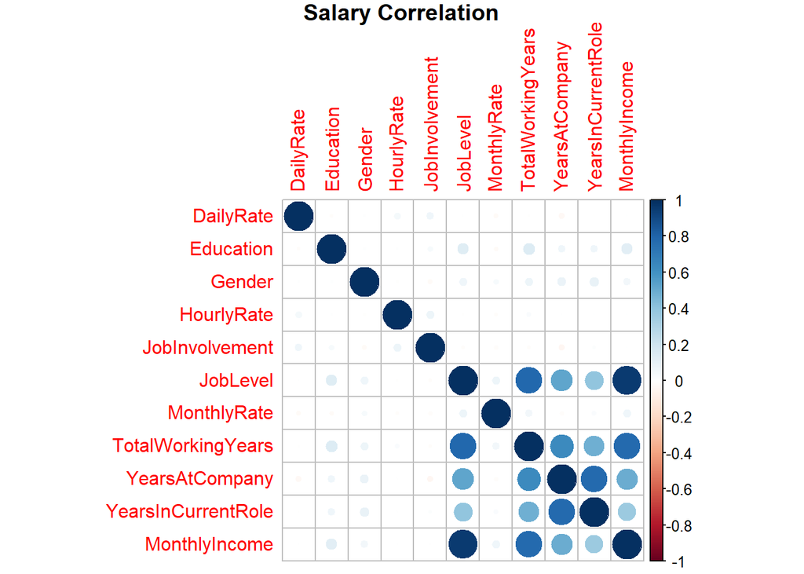

```r
# Columns that could be used to determine MonthlyIncome[20]
# DailyRate[5], Education[8], Gender[13] "unfortuantly prob a factor", HourlyRate[9],
# JobInvolvement[10], JobLevel[11], MonthlyRate[21], TotalWorkingYears[30], YearsAtCompany[33],
# YearsInCurrentRole[34]

# Create DataFrame
income_pred_data <- subset(comp_set, select = c(MonthlyIncome, DailyRate, Education, Gender, HourlyRate,
                                       JobInvolvement, JobLevel, MonthlyRate, TotalWorkingYears,
                                       YearsAtCompany, YearsInCurrentRole))
# Replace Gender with 0 and 1
income_pred_data$Gender <- replace(income_pred_data$Gender, income_pred_data$Gender=="Male", 0)
income_pred_data$Gender <- replace(income_pred_data$Gender, income_pred_data$Gender=="Female", 1)

# Create a normalized version to create correlation table
income_pred_data <- as.data.frame(lapply(income_pred_data, as.numeric))
income_pred_data_norm <- as.data.frame(lapply(income_pred_data[c(2:11)], min_max_norm))
income_pred_data_norm$MonthlyIncome <- income_pred_data$MonthlyIncome

# Plot Correlation
income_pred_data_cor <- cor(income_pred_data_norm)
corrplot(income_pred_data_cor, title="Salary Correlation", mar=c(0,0,1,0))
```

```r
# Based on the chart these are the categories that provide little to no-impact
# DailyRate, HourlyRate, and JobInvolvement(little surprisng)

# Create formula outside of the model creation because it can't pick up the Env
pred_fx <- as.formula(MonthlyIncome ~ JobLevel + TotalWorkingYears + YearsAtCompany +
                       YearsInCurrentRole + Education + MonthlyRate + Gender)

# Creating this Linear model
income_pred_data_model <- lm(pred_fx, data=income_pred_data_norm)

# Print out summary of our model
summary(income_pred_data_model)
```

```
##
## Call:
## lm(formula = pred_fx, data = income_pred_data_norm)
##
## Residuals:
##     Min      1Q  Median      3Q     Max
## -5688.8  -905.2    43.8   742.5  3869.2
##
## Coefficients:
##                    Estimate Std. Error t value Pr(>|t|)
## (Intercept)         2092.25     146.19  14.312  < 2e-16 ***
## JobLevel           14911.72     276.51  53.929  < 2e-16 ***
## TotalWorkingYears   2853.64     444.73   6.417  2.3e-10 ***
## YearsAtCompany      -880.33     563.88  -1.561    0.119
## YearsInCurrentRole  -388.70     369.51  -1.052    0.293
## Education            -42.64     185.86  -0.229    0.819
## MonthlyRate         -125.15     165.82  -0.755    0.451
## Gender               -94.30      96.00  -0.982    0.326
## ---
## Signif. codes:  0 '***' 0.001 '**' 0.01 '*' 0.05 '.' 0.1 ' ' 1
##
## Residual standard error: 1383 on 862 degrees of freedom
## Multiple R-squared:  0.9102, Adjusted R-squared:  0.9095
## F-statistic:  1248 on 7 and 862 DF,  p-value: < 2.2e-16
```

```r
# Print out confidence interval of model
confint(income_pred_data_model, conf.level=0.95)
```

```
##                         2.5 %      97.5 %
## (Intercept)         1805.3183  2379.17435
## JobLevel           14369.0165 15454.42954
## TotalWorkingYears   1980.7666  3726.51208
## YearsAtCompany     -1987.0554   226.40445
## YearsInCurrentRole -1113.9454   336.54110
## Education           -407.4325   322.15919
## MonthlyRate         -450.6161   200.30612
## Gender              -282.7178    94.12395
```

```r
# Create a prediction using original normalized data
prediction <- as.data.frame(predict(income_pred_data_model, newdata=income_pred_data_norm))
colnames(prediction) <-c("MonthlyIncome")

# Create data frame to compare original data to the results
compare_predictions <- data.frame(Original=income_pred_data_norm$MonthlyIncome,
                                  Predicted=prediction$MonthlyIncome)

# Create column with difference in percentage
compare_predictions$PercentDifference <- with(compare_predictions,
                                              abs((Original-Predicted)/(Original+Predicted)))

# Print summary of results
summary(compare_predictions$PercentDifference)
```

```
##      Min.   1st Qu.    Median      Mean   3rd Qu.      Max.
## 0.0002928 0.0343743 0.0776199 0.0988025 0.1428431 0.5374391
```

```r
# On average my model predicts Monthly Income with a mean difference of 9%
# and a median of 7%. Besides a couple high max values this model isn't bad.

# Change compare_preduictions$original to a numeric to work with rmse()
compare_predictions$Predicted <- as.numeric(compare_predictions$Predicted)

# Generate the ROOT MEAN SQUARE (RMSE)
pred_rsme <- sqrt(mean((compare_predictions$Original - compare_predictions$Predicted)^2))
paste("The RMSE = ", as.character(pred_rsme), sep=' ')
```

```
## [1] "The RMSE =  1376.95372578543"
```

```r
# Now lets apply this model to predict to income for the no_salary_data
# Create data frame to temporarly use
emp_salary_predict <- subset(comp_set_no_salary, select=c(JobLevel, TotalWorkingYears, YearsAtCompany,
                        YearsInCurrentRole,Education, MonthlyRate, Gender))
# "Normalize" the data
# Assign Gender a 1 or 0
emp_salary_predict$Gender <- replace(emp_salary_predict$Gender, emp_salary_predict$Gender=="Male", 0)
emp_salary_predict$Gender <- replace(emp_salary_predict$Gender, emp_salary_predict$Gender=="Female", 1)
# Changes columns to numeric
emp_salary_predict <- as.data.frame(lapply(emp_salary_predict, as.numeric))
# Apply normalization function to data
emp_salary_predict <- as.data.frame(lapply(emp_salary_predict[1:7], min_max_norm))
# Create data frame with predictions
no_salary_prediction <- as.data.frame(predict(income_pred_data_model, newdata=emp_salary_predict))
# Rename column to make it easier to merge back in
colnames(no_salary_prediction) <-c("MonthlyIncome")

# Add the new column back to the no_salary data
comp_set_no_salary$MonthlyIncome <- no_salary_prediction$MonthlyIncome
```

# Combine Data Sets for Analysis

```r
# Create data frame from the two datasets the provide "attrition"
emp_data <- full_join(comp_set, comp_set_no_salary)
```

# Split Data for Attrtion EDA

```r
# Split data into two sets for Attrition=Yes, or Attrition=No
emp_data_attr_yes <- filter(emp_data, emp_data$Attrition=="Yes")
emp_data_attr_no <- filter(emp_data, emp_data$Attrition=="No")
```

# Start EDA

#### Categorical Variables

Attrition, Business Travel, Department, ’Education, EducationField, Gender, ’JobInvolvement, ’JobLevel, JobRole, ’JobSatisfaction, MaritalStatus, Over18, OverTime, ’PerformanceRating, RelationshipSatisfaction, ’WorkLifeBalance

#### Constant Variables

Age, Daily Rate, DistanceFromHome, EnvironmentSatisfaction, HourlyRate, MonthlyIncome, MonthlyRate, NumCompaniesWorked, PercentSalaryHike, StockOptions, TotalWorkingYears, TrainingTimesLastYear, YearsAtCompany,YearsInCurrentRole, YearsSinceLastPromotion, YearsWithCurrentManager

#### Suspected Non-Factors

ID, EmployeeCount, EmployeeNumber, StandardHours(They all seem to be 80)

# Create Charts to find variables that could carry a more significant weight

### Click “Code” on the right to show code behind charts –>

```r
# Compare variables by Comparing the average of all employees data-set to the
# average of emplyoees with No attrition and those with attrition

# I could have writted a function to do all this but I wanted to add subtitles
# into the some of the charts

# Age
age_den <- data.frame(age=emp_data$Age, type="All_Employees")
age_den <- rbind(age_den, data.frame(age=emp_data_attr_no$Age, type="No_Attrition"))
age_den <- rbind(age_den, data.frame(age=emp_data_attr_yes$Age, type="Attrition"))
# Plot Age
ggplot(age_den, aes(x=age, fill=type)) + geom_density(alpha=0.5) + ggtitle("Age") +
  labs(subtitle = "Mean: All Employees=36.68 | No Attrition=37.34 | Attrition=33.79")

# Daily_Rate
daily_rate_den <- data.frame(DailyRate=emp_data$DailyRate, type="All_Employees")
daily_rate_den <- rbind(daily_rate_den, data.frame(DailyRate=emp_data_attr_no$DailyRate, type="No_Attrition"))
daily_rate_den <- rbind(daily_rate_den, data.frame(DailyRate=emp_data_attr_yes$DailyRate, type="Attrition"))
# Plot Daily Rate
ggplot(daily_rate_den, aes(x=DailyRate, fill=type)) + geom_density(alpha=0.5) + ggtitle("Daily Rate") +
  labs(subtitle = "Mean: All-Employees=807.02 | No_Attrition=816.80 | Attrition=756.91")

# Business Travel
buss_travl_den <- data.frame(Travel=emp_data_attr_no$BusinessTravel, type="No_Attrition")
buss_travl_den <- rbind(buss_travl_den,
                        data.frame(Travel=emp_data_attr_yes$BusinessTravel, type="Attrition"))
# Plot Business Travel
ggplot(buss_travl_den, aes(x=Travel, fill=type)) + geom_bar(position="dodge") + ggtitle("Business Travel") +
    geom_text(aes(label=..count..), position = position_dodge(.9), stat = "count", vjust = -.2)

# Department
dept_den <- data.frame(dept=emp_data_attr_no$Department, type="No_Attrition")
dept_den <- rbind(dept_den, data.frame(dept=emp_data_attr_yes$Department, type="Attrition"))
# Plot Department Attrition vs No_Attrition
ggplot(dept_den, aes(x=dept, fill=type)) + geom_bar(position="dodge") + ggtitle("Employee Department") +
  geom_text(aes(label=..count..), position = position_dodge(.9), stat = "count", vjust = -.2)

# Distance from Home
dist_home_den <- data.frame(dist=emp_data$DistanceFromHome, type="All_Employees")
dist_home_den <- rbind(dist_home_den, data.frame(dist=emp_data_attr_no$DistanceFromHome, type="No_Attrition"))
dist_home_den <- rbind(dist_home_den, data.frame(dist=emp_data_attr_yes$DistanceFromHome, type="Attrition"))
# plot Distance from home
ggplot(dist_home_den, aes(x=dist, fill=type)) + geom_density(alpha=0.5) + ggtitle("Distance From Home") +
  labs(subtitle = "Mean: All-Employees=9.17 | No Attrition=8.86 | Attrition=10.74")

# Education (level 1-4)
edu_lvl_den <- data.frame(edu_lvl=emp_data_attr_no$Education, type="No_Attrition")
edu_lvl_den <- rbind(edu_lvl_den, data.frame(edu_lvl=emp_data_attr_yes$Education, type="Attrition"))
# Plot Education Level
ggplot(edu_lvl_den, aes(x=edu_lvl, fill=type)) + geom_bar(position="dodge") +
  ggtitle("Education Level") + xlab("Level of Education") +
  geom_text(aes(label=..count..), position = position_dodge(.9), stat = "count", vjust = -.2)

# Education Field
edu_field_den <- data.frame(edu_field=emp_data_attr_no$EducationField, type="No_Attrition")
edu_field_den <- rbind(edu_field_den, data.frame(edu_field=emp_data_attr_yes$EducationField, type="Attrition"))
# Plot Education Field
ggplot(edu_field_den, aes(x=edu_field, fill=type)) + geom_bar(position="dodge") +
  ggtitle("Education Field") + xlab("Field of Education") +
  geom_text(aes(label=..count..), position = position_dodge(.9), stat = "count", vjust = -.2)

# Environment Satisfaction
env_stsfctn_den <- data.frame(env_stsfctn=emp_data_attr_no$EnvironmentSatisfaction,
                              type="No_Attrition")
env_stsfctn_den <- rbind(env_stsfctn_den, data.frame(env_stsfctn=emp_data_attr_yes$EnvironmentSatisfaction,
                                                     type="Attrition"))
# Plot Env Satisfaction
ggplot(env_stsfctn_den, aes(x=env_stsfctn, fill=type)) + geom_bar(position="dodge") +
  ggtitle("Environment Satisfaction") + xlab("Env Satisfaction") +
  geom_text(aes(label=..count..), position = position_dodge(.9), stat = "count", vjust = -.2)

# gender
gender_den <- data.frame(gender=emp_data_attr_no$Gender, type="No_Attrition")
gender_den <- rbind(gender_den, data.frame(gender=emp_data_attr_yes$Gender, type="Attrition"))
# Plot gender
ggplot(gender_den, aes(x=gender, fill=type)) + geom_bar(position="dodge") +
  ggtitle("Gender") + xlab("Gender") +
  geom_text(aes(label=..count..), position = position_dodge(.9), stat = "count", vjust = -.2)

# Hourly Rate
hr_rate_den <- data.frame(hr_rate=emp_data_attr_no$HourlyRate, type="No_Attrition")
hr_rate_den <- rbind(hr_rate_den, data.frame(hr_rate=emp_data_attr_yes$HourlyRate, type="Attrition"))
# plot Hourly Rate  -> Not sure this variable will be as usefull
ggplot(hr_rate_den, aes(x=hr_rate, fill=type)) + geom_density(alpha=0.5) + ggtitle("Hourly Rate") +
  labs(subtitle = "Mean: No Attrition=65.70 | Attrition=66.55")

# Job Involvement
job_involve_den <- data.frame(job_involve=emp_data_attr_no$JobInvolvement, type="No_Attrition")
job_involve_den <- rbind(job_involve_den, data.frame(job_involve=emp_data_attr_yes$JobInvolvement,
                                                     type="Attrition"))
# Plot Job Involvment
ggplot(job_involve_den, aes(x=job_involve, fill=type)) + geom_bar(position="dodge") +
  ggtitle("Job Involvement") + xlab("job_involvement") +
  geom_text(aes(label=..count..), position = position_dodge(.9), stat = "count", vjust = -.2)

# Job Level
job_lvl_den <- data.frame(job_lvl=emp_data_attr_no$JobLevel, type="No_Attrition")
job_lvl_den <- rbind(job_lvl_den, data.frame(job_lvl=emp_data_attr_yes$JobLevel, type="Attrition"))
# Plot Job Level
ggplot(job_lvl_den, aes(x=job_lvl, fill=type)) + geom_bar(position="dodge") +
  ggtitle("Job Level") + xlab("Job Level") +
  geom_text(aes(label=..count..), position = position_dodge(.9), stat = "count", vjust = -.2)
```

```r
# Job Role
job_role_den <- data.frame(job_role=emp_data_attr_no$JobRole, type="No_Attrition")
job_role_den <- rbind(job_role_den, data.frame(job_role=emp_data_attr_yes$JobRole, type="Attrition"))
# Plot Job Role
ggplot(job_role_den, aes(x=job_role, fill=type)) + geom_bar(position="dodge") +
  ggtitle("Job Role") + xlab("Job Role") +
  geom_text(aes(label=..count..), position = position_dodge(.9), stat = "count", vjust = -.2) +
  theme(axis.text.x = element_text(angle = 90, size = 5))

# Job Satisfation
job_sat_den <- data.frame(job_sat=emp_data_attr_no$JobSatisfaction, type="No_Attrition")
job_sat_den <- rbind(job_sat_den, data.frame(job_sat=emp_data_attr_yes$JobSatisfaction, type="Attrition"))
# Plot Satisfaction
ggplot(job_sat_den, aes(x=job_sat, fill=type)) + geom_bar(position="dodge") +
  ggtitle("Job Satisfaction") + xlab("Job Satisfaction") +
  geom_text(aes(label=..count..), position = position_dodge(.9), stat = "count", vjust = -.2)

# Marital Status
marital_stat_den <- data.frame(marital_stat=emp_data_attr_no$MaritalStatus, type="No_Attrition")
marital_stat_den <- rbind(marital_stat_den, data.frame(marital_stat=emp_data_attr_yes$MaritalStatus,
                                                       type="Attrition"))
# Marital Status
ggplot(marital_stat_den, aes(x=marital_stat, fill=type)) + geom_bar(position="dodge") +
  ggtitle("Marital Status") + xlab("Marital Status") +
  geom_text(aes(label=..count..), position = position_dodge(.9), stat = "count", vjust = -.2)

# Monthly Rate
mnth_rate_den <- data.frame(mnth_rate=emp_data_attr_no$MonthlyRate, type="No_Attrition")
mnth_rate_den <- rbind(mnth_rate_den, data.frame(mnth_rate=emp_data_attr_yes$MonthlyRate, type="Attrition"))
# plot Monthly Rate
ggplot(mnth_rate_den, aes(x=mnth_rate, fill=type)) + geom_density(alpha=0.5) + ggtitle("Monthly Rate") +
  labs(subtitle = "Mean: No Attrition=14274.31 | Attrition=14219.31")

# Number of Companies Worked for
num_of_comp_den <- data.frame(num_of_comp=emp_data_attr_no$NumCompaniesWorked, type="No_Attrition")
num_of_comp_den <- rbind(num_of_comp_den, data.frame(num_of_comp=emp_data_attr_yes$NumCompaniesWorked,
                                                       type="Attrition"))
# Plot number of companies worked for
ggplot(num_of_comp_den, aes(x=num_of_comp, fill=type)) + geom_bar(position="dodge") +
  ggtitle("Number of Companies Worked for") + xlab("Number of Companies Worked for") +
  geom_text(aes(label=..count..), position = position_dodge(.9), stat = "count", vjust = -.2)

# Overtime
ot_den <- data.frame(ot=emp_data_attr_no$OverTime, type="No_Attrition")
ot_den <- rbind(ot_den, data.frame(ot=emp_data_attr_yes$OverTime, type="Attrition"))
# Plot Overtime
ggplot(ot_den, aes(x=ot, fill=type)) + geom_bar(position="dodge") +
  ggtitle("Overtime") + xlab("Overtime") +
  geom_text(aes(label=..count..), position = position_dodge(.9), stat = "count", vjust = -.2)

# Percentage of Salary Hike
slry_hike_den <- data.frame(slry_hike=emp_data_attr_no$PercentSalaryHike, type="No_Attrition")
slry_hike_den <- rbind(slry_hike_den, data.frame(slry_hike=emp_data_attr_yes$PercentSalaryHike,
                                                 type="Attrition"))
# plot Percentage of Salary Hike ## Not as impactfull as I thought
ggplot(slry_hike_den, aes(x=slry_hike, fill=type)) + geom_density(alpha=0.5) +
  ggtitle("Percentage Salary Increase") +
  labs(subtitle = "Mean: No Attrition=15.23 | Attrition=15.14")

# Relationship Satisfaction (With manager??)
rel_satfctn_den <- data.frame(rel_satfct=emp_data_attr_no$RelationshipSatisfaction, type="No_Attrition")
rel_satfctn_den <- rbind(rel_satfctn_den, data.frame(rel_satfct=emp_data_attr_yes$RelationshipSatisfaction,
                                                     type="Attrition"))
# Plot Relationship Satisfaction
ggplot(rel_satfctn_den, aes(x=rel_satfct, fill=type)) + geom_bar(position="dodge") +
  ggtitle("Relationship Satisfaction") + xlab("Relationship Satisfaction") +
  geom_text(aes(label=..count..), position = position_dodge(.9), stat = "count", vjust = -.2)

# StockOptionLevel
stck_opt_den <- data.frame(stck_opt=emp_data_attr_no$StockOptionLevel, type="No_Attrition")
stck_opt_den <- rbind(stck_opt_den, data.frame(stck_opt=emp_data_attr_yes$StockOptionLevel,
                                                     type="Attrition"))
# Plot StockOptionLevel
ggplot(stck_opt_den, aes(x=stck_opt, fill=type)) + geom_bar(position="dodge") +
  ggtitle("Stock Option Level") + xlab("StockOptionLevel") +
  geom_text(aes(label=..count..), position = position_dodge(.9), stat = "count", vjust = -.2)

# Total Working Years
ttl_wrk_yrs_den <- data.frame(ttl_wrk_yrs=emp_data_attr_no$TotalWorkingYears, type="No_Attrition")
ttl_wrk_yrs_den <- rbind(ttl_wrk_yrs_den, data.frame(ttl_wrk_yrs=emp_data_attr_yes$TotalWorkingYears,
                                                 type="Attrition"))
# plot Total working years
ggplot(ttl_wrk_yrs_den, aes(x=ttl_wrk_yrs, fill=type)) + geom_density(alpha=0.5) +
  ggtitle("Total Working Years") +
  labs(subtitle = "Mean: No Attrition=11.46 | Attrition=8.49")

# Training Times Last Year
train_time_den <- data.frame(train_time=emp_data_attr_no$TrainingTimesLastYear, type="No_Attrition")
train_time_den <- rbind(train_time_den, data.frame(train_time=emp_data_attr_yes$TrainingTimesLastYear,
                                                     type="Attrition"))
# Plot Training Times Last Year
ggplot(train_time_den, aes(x=train_time, fill=type)) + geom_bar(position="dodge") +
  ggtitle("Last Years Training Times") + xlab("TrainingTimesLastYear") +
  geom_text(aes(label=..count..), position = position_dodge(.9), stat = "count", vjust = -.2)

# Work Life Balance
wrk_life_den <- data.frame(wrk_life=emp_data_attr_no$WorkLifeBalance, type="No_Attrition")
wrk_life_den <- rbind(wrk_life_den, data.frame(wrk_life=emp_data_attr_yes$WorkLifeBalance,
                                                     type="Attrition"))
# Plot Work Life Balance
ggplot(wrk_life_den, aes(x=wrk_life, fill=type)) + geom_bar(position="dodge") +
  ggtitle("Work Life Balance") + xlab("Work Life Balance") +
  geom_text(aes(label=..count..), position = position_dodge(.9), stat = "count", vjust = -.2)
```

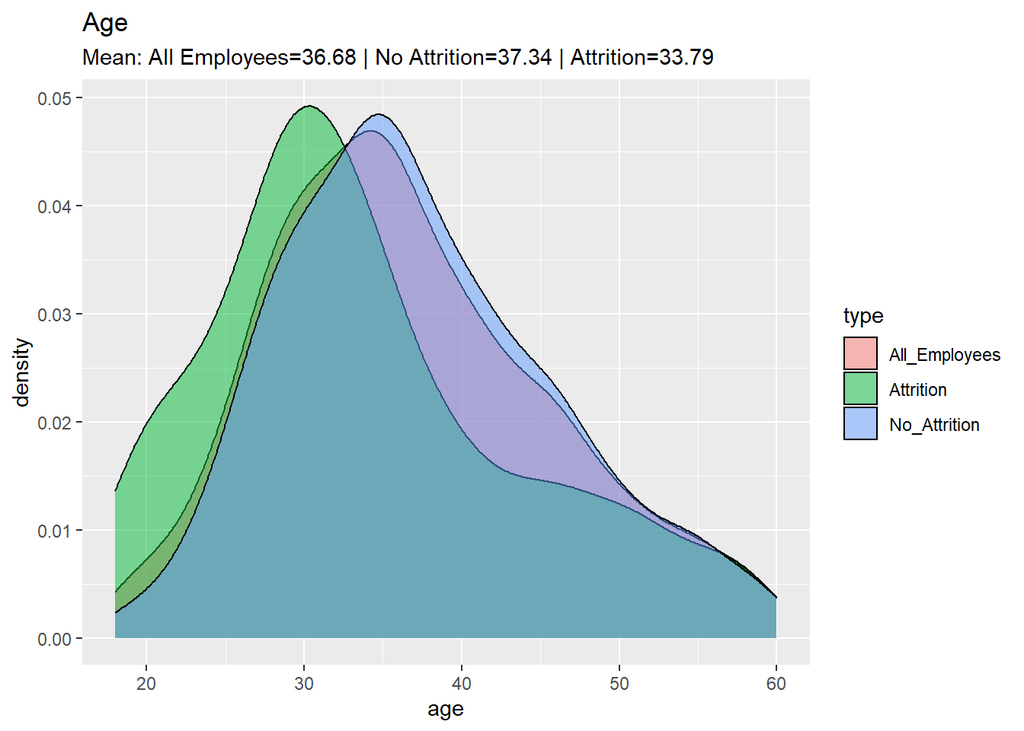

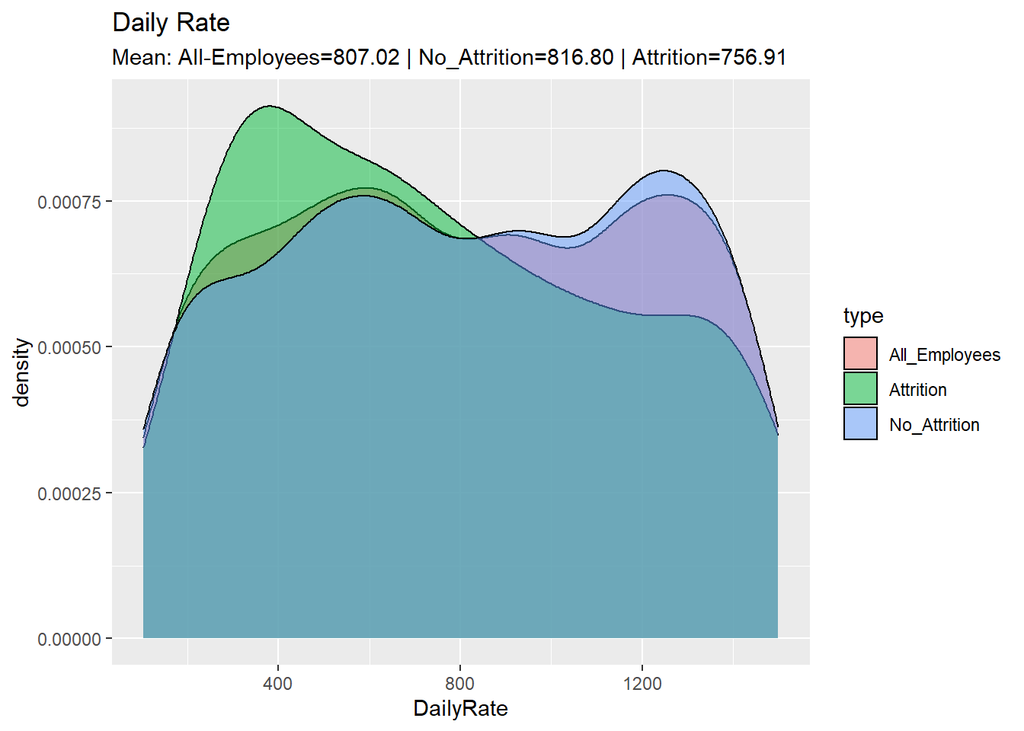

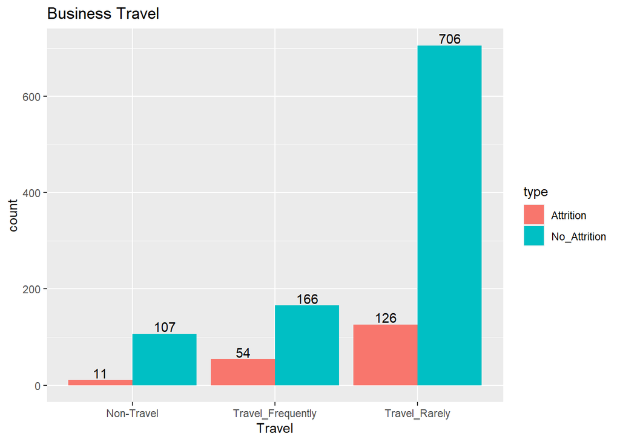

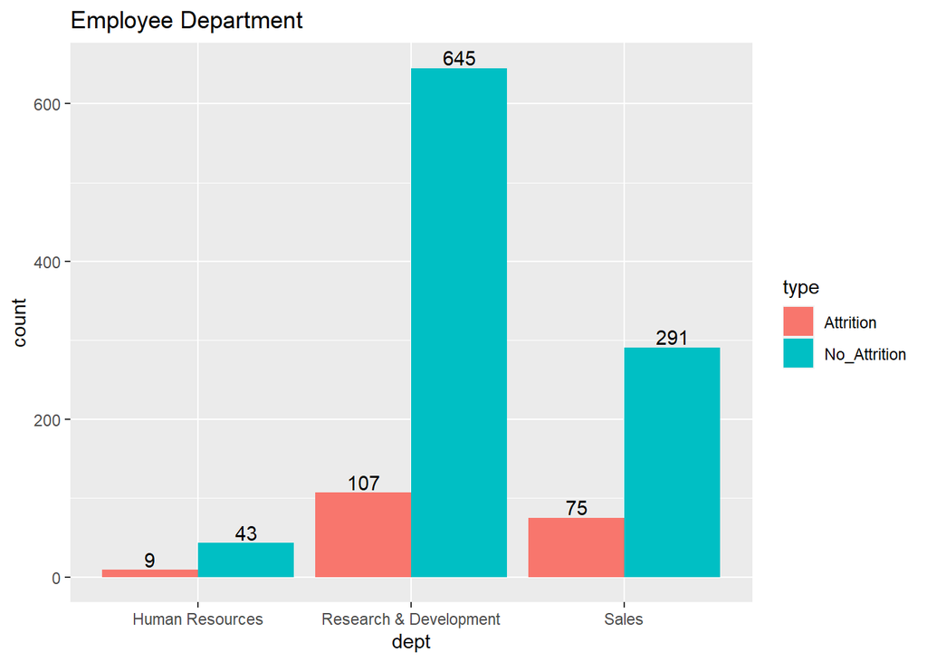

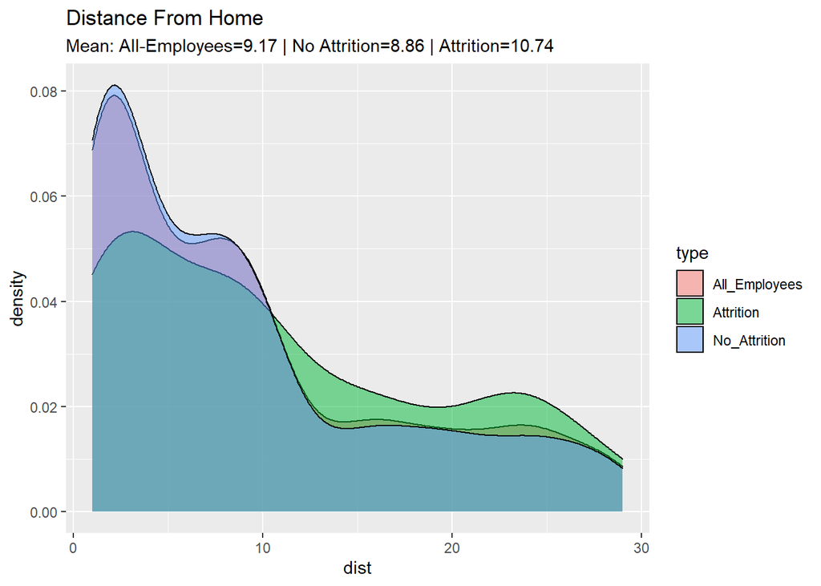

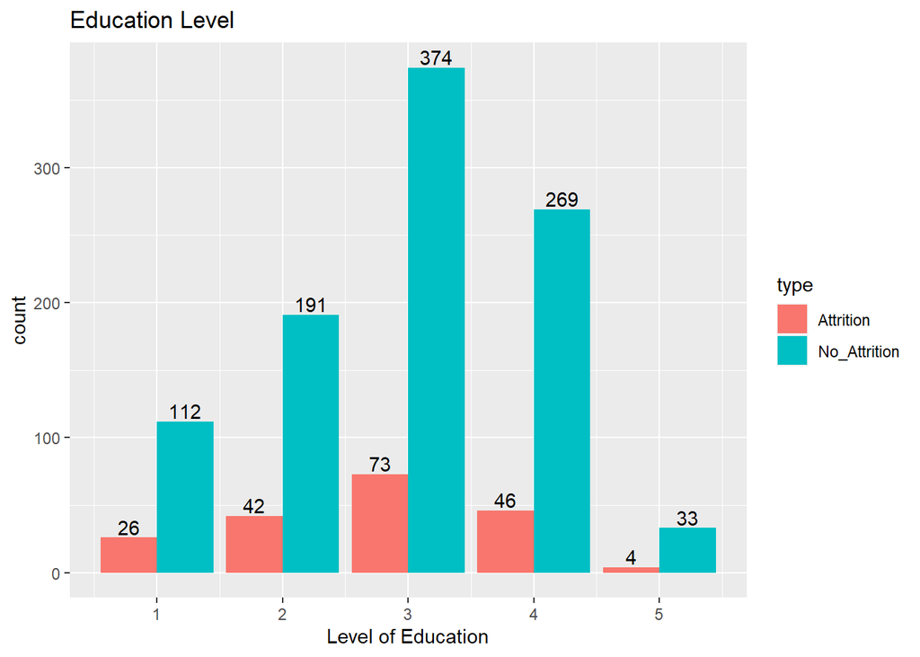

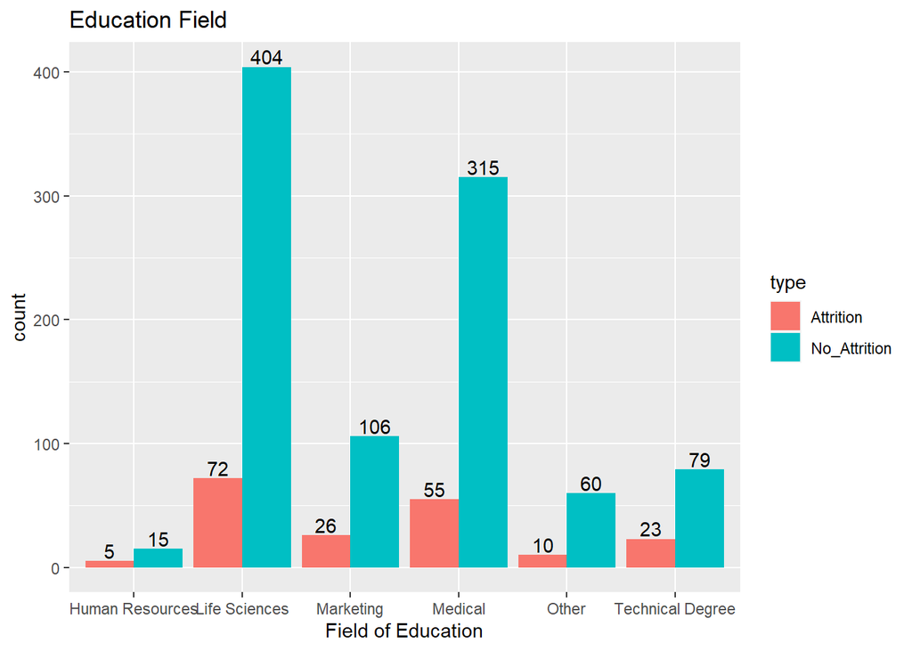

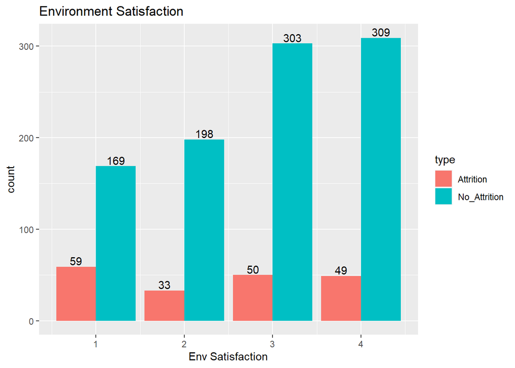

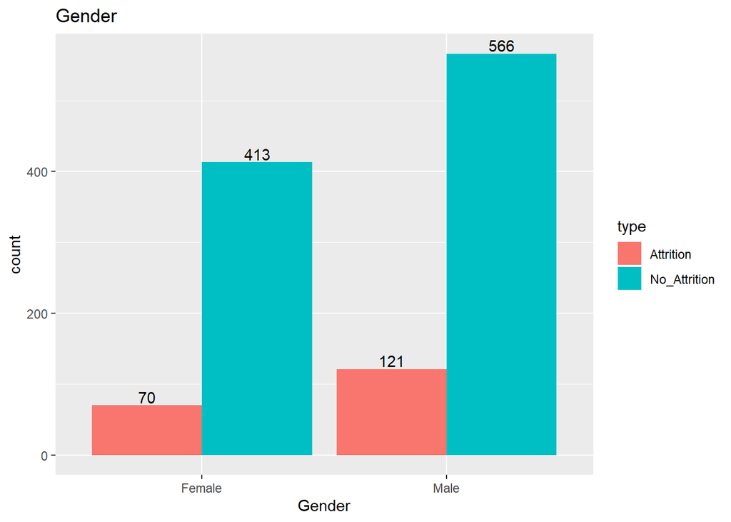

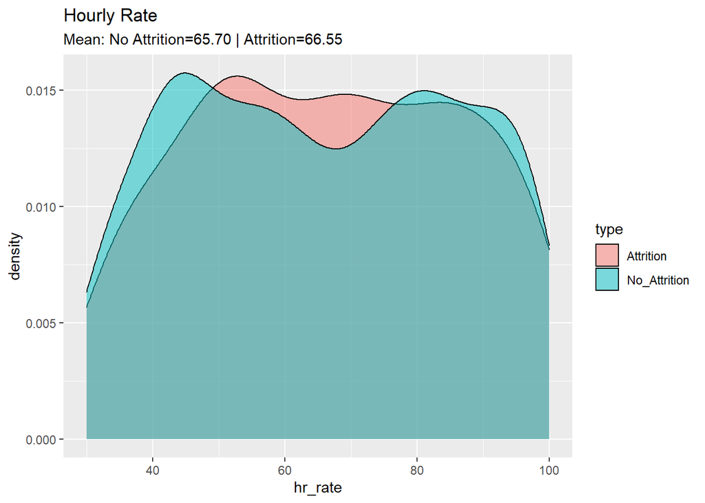

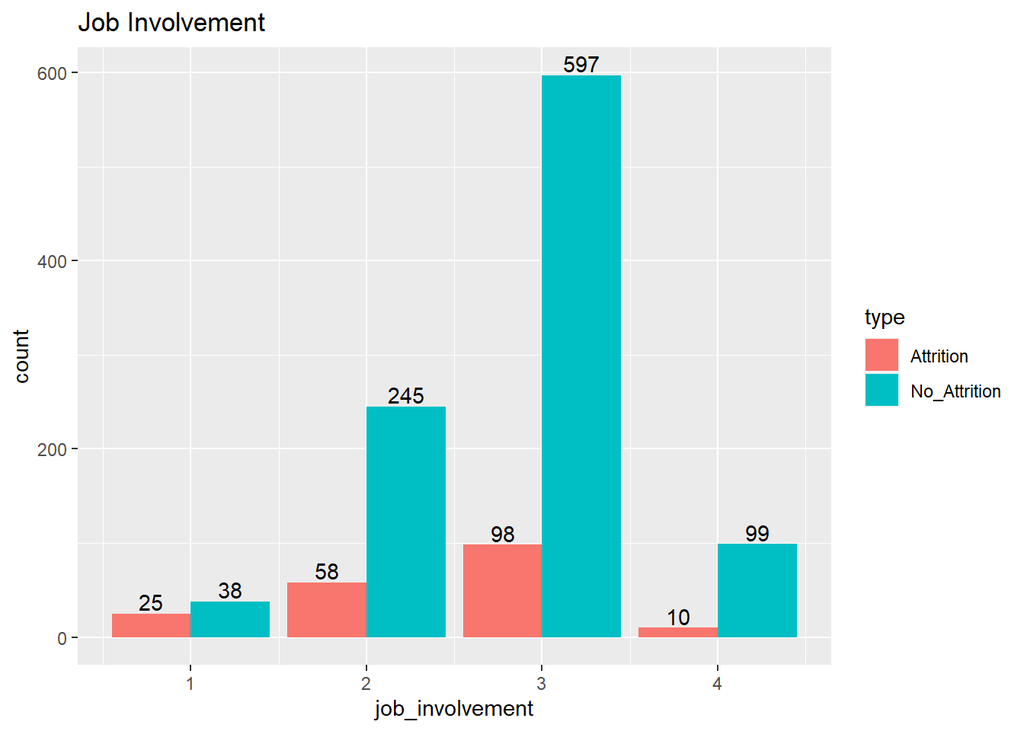

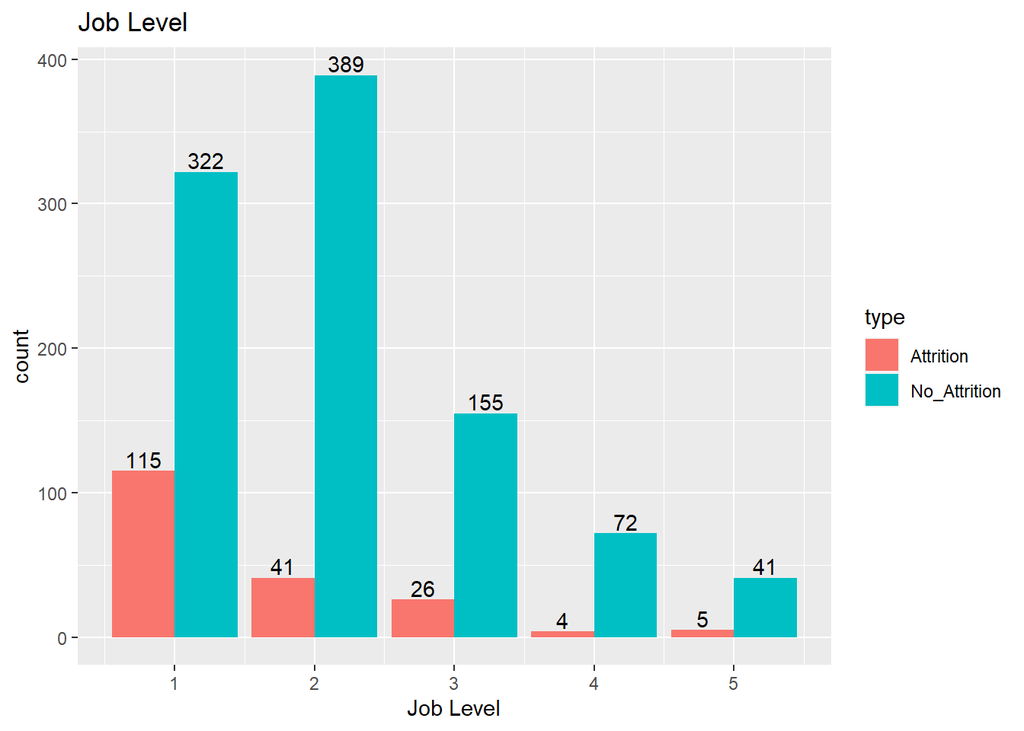

[17 more figures not shown]

```r
# Years At Company
yrs_at_comp_den <- data.frame(yrs_at_comp=emp_data_attr_no$YearsAtCompany, type="No_Attrition")
yrs_at_comp_den <- rbind(yrs_at_comp_den, data.frame(yrs_at_comp=emp_data_attr_yes$YearsAtCompany,
                                                     type="Attrition"))
# Plot Years At Company
ggplot(yrs_at_comp_den, aes(x=yrs_at_comp, fill=type)) + geom_density(alpha=0.5) +
  ggtitle("Years at company") +
  labs(subtitle = "Mean: No Attrition=7.19 | Attrition=5.21")

# Years in current role
yrs_in_role_den <- data.frame(yrs_in_role=emp_data_attr_no$YearsInCurrentRole, type="No_Attrition")
yrs_in_role_den <- rbind(yrs_in_role_den, data.frame(yrs_in_role=emp_data_attr_yes$YearsInCurrentRole,
                                                     type="Attrition"))
# Plot Years in current role
ggplot(yrs_in_role_den, aes(x=yrs_in_role, fill=type)) + geom_density(alpha=0.5) +
  ggtitle("Years in current role") +
  labs(subtitle = "Mean: No Attrition=4.46 | Attrition=2.85")

# years since last promotion
last_prmtn_den <- data.frame(last_prmtn=emp_data_attr_no$YearsSinceLastPromotion, type="No_Attrition")
last_prmtn_den <- rbind(last_prmtn_den,
                        data.frame(last_prmtn=emp_data_attr_yes$YearsSinceLastPromotion, type="Attrition"))
# Plot Years since last promotion
ggplot(last_prmtn_den, aes(x=last_prmtn, fill=type)) + geom_boxplot() +
  ggtitle("Years since last promotion")

# Years with current manager
yrs_cur_mngr_den <- data.frame(yrs_cur_mngr=emp_data_attr_no$YearsWithCurrManager, type="No_Attrition")
yrs_cur_mngr_den <- rbind(yrs_cur_mngr_den,
                          data.frame(yrs_cur_mngr=emp_data_attr_yes$YearsWithCurrManager,
                                                     type="Attrition"))
# Plot Years with current manager
ggplot(yrs_cur_mngr_den, aes(x=yrs_cur_mngr, fill=type)) + geom_density(alpha=0.5) +
  ggtitle("Years with current manager") +
  labs(subtitle = "Mean: No Attrition=4.29 | Attrition=2.83")


# Years with current manager
monthly_inc_den <- data.frame(monthly_inc=emp_data_attr_no$MonthlyIncome, type="No_Attrition")
monthly_inc_den <- rbind(monthly_inc_den,
                          data.frame(monthly_inc=emp_data_attr_yes$MonthlyIncome, type="Attrition"))
# Plot Monthly Income
ggplot(monthly_inc_den, aes(x=monthly_inc, fill=type)) + geom_density(alpha=0.5) +
  ggtitle("Monthly Income") +
  labs(subtitle = "Mean: No Attrition=6630.38 | Attrition=4844.37")
```

# Notes from Initial Variables

- All percentags are for those who have Attrition

### Age

- Mean -> Attrition: 33.79 | No-Attrition: 37.34
- The age of employees is notably younger

### Daily Rate

- Mean -> Attrition: 756.91, No-Attrition: 816.80
- The daily rate is lower for those with attrition

### Business Travel

- Non-Travel: 9.3%
- Travel-Frequently: 24.54%
- Travel-Rarely: 15.14%
- Seems those who have to travel frequently have a more likelyhood of attrition

### Employee Department

- HR: 17.3%
- R&D: 14.23%
- Sales: 20.49%
- Those in Sales and HR have a little higher attrition rate

### Distance from Home

- Mean -> Attrition: 10.74 | No-Attrition: 8.86
- Those who lived closer to work had a lower chance of Attrition
- A majority of those with no attrition lived within 5 miles

### Education Level

- 1: 18.84%
- 2: 18.03%
- 3: 16.33%
- 4: 14.60%
- 5: 10.81%
- These all seem to fall in line with eachother
- The only difference is the level 5 education with a small sample size
- Not sure this values carries a big enough wieght to be used effectively

### Education Field

- HR: 25%
- Life Science: 15%
- Marketing: 19.7%
- Medical: 14.86%
- Other: 14.29%
- Technical Degree: 22.55
- Seems HR, Marketing, and Tech Degrees have the most with with attrition

### Environment Satisfaction

- 1: 25.88%
- 2: 14.29%
- 3: 14.16%
- 4: 13.69%
- As Env satisfaction goes up, attrition goes down (No Surprise there)

### Hourly Rate

- Mean -> Attrition: 66.55 | No-Attrition: 65.70
- Looking at the chart doesn’t reveal much
- Potentially not going to use this data

### Job Involvement

- 1: 39.68%
- 2: 19.14%
- 3: 14.1%
- 4: 9.17%
- This is a heavy weight! Low job involvement is something to look at

### Job Level

- 1: 26.32%
- 2: 9.53%
- 3: 14.36%
- 4: 5.26%
- 5: 10.87%
- Levels 3 and 5 have a higher rate, but level 1 stands above the rest

### Job Role

- Healthcare Rep: 7.84%
- HR: 20.45%
- Lab Tech: 22.55%
- Manager: 6.94%
- Manufacturing Dir: 7.02%
- Research Dir: 3.23%
- Research Scientist: 17.32%
- Sales Exec: 15.99%
- Sales Rep: 41.66%
- Highest attrition goes to Sales Rep with a whopping 41.66% attrition
- Honorable mentions go to HR, Lab Techs, Research Scientest, and  
  sales execs

### Job Satisfaction

- 1: 22.03%
- 2: 16.74%
- 3: 17.48%
- 4: 11.26%
- Slight up-tick when the job satisfaction is at a 1

### Marital Status

- Divorced: 9.16%
- Married: 13.21%
- Single: 26.17%
- Personal opinion leads me to think that the reason Single employees have a  
  higher attrition could be due having the flexibility of switching careers  
  without having to be restricted (respectively) by family.

### Number of Companies Worked for before

- 0: 11.5%, 1: 18.4%, 2: 12.5%, 3: 10.32%, 4: 10.91%, 5: 24.1%, 6: 25.9%,  
  7: 23.8%, 8: 12.5%, 9: 25.0%
- Noticable increase in attrition as employees have more previous jobs

### Overtime

- No: 10.1%
- Yes: 32.32%
- Big increase in Attrition when overtime is involved

### Percentage Salary Increase

- Mean-> Attrition: 15.14 | No-Attrition: 15.23
- While the means are roughly the same the density chart shows a heavy right  
  skew and where the salary hike is less than 15% the attrition is much higher

### Relationship Satisfaction

- 1: 20.52%
- 2: 15.66%
- 3: 14.33%
- 4: 16.03%
- Not the biggest contribution, but enough to provide a push towards attrition

### Stock Option Level

- 0: 25.2%
- 1: 9.5%
- 2: 5.7%
- 3: 19.12%
- I’m not sure what to make of this, but I will assume that young employees  
  aren’t eligable to get stock option. Could be very expensive to offer though.

### Total Working Years

- Mean-> Attrition: 8.49 | No-Attrition: 11.46

### Percentage Salary Increases

- Mean-> Attrition: 15.14 | No-Attrition: 15.23

### Training time from last year

- 0: 21.4%, 1: 12.7%, 2: 19.0%, 3: 13.7%, 4: 22.68%, 5: 13.1%, 6: 9.6%
- Data doesn’t seem to be too specific
- I would like to test the training times of new (>2years) emlpoyees

### Work life Balance

- 1: 31.8%
- 2: 16.5%
- 3: 14.9%
- 4: 16.13%
- Again not really a surprise

### Years at company

- Mean-> Attrition: 5.21 | No-Attrition: 7.19
- Attrition really spikes with years less that 7

### Years in Current Role

- Mean-> Attrition: 2.85 | No-Attrition: 4.46
- Much like the “years at company” it follows the same pattern
- Although big drop off after 5 years, small spike at 7 and drop off again

### Years since last promotion

- The mean of the two stayed releativly the same, but attrition seemed to  
  stay in the 0-2 range

### Years with Current Manager

- Mean-> Attrition: 2.83 | No-Attrition: 4.29
- Follows some pattern as other time based charts

### Monthly Income

- Mean-> Attrition: 4,844.37 | No-Attrition: 6,630.38
- Those with attrition has a much lower income

# Clean-Up Data

```r
## Cleanup some variables to free space and clutter
rm(list=c("age_den", "daily_rate_den", "buss_travl_den", "dept_den",
          "dist_home_den", "edu_lvl_den", "edu_field_den", "env_stsfctn_den",
          "gender_den", "hr_rate_den", "job_involve_den", "job_lvl_den",
          "job_role_den", "job_sat_den", "marital_stat_den", "mnth_rate_den",
          "num_of_comp_den", "ot_den", "slry_hike_den", "rel_satfctn_den",
          "stck_opt_den", "ttl_wrk_yrs_den", "train_time_den", "wrk_life_den",
          "yrs_at_comp_den", "yrs_in_role_den", "last_prmtn_den",
          "yrs_cur_mngr_den", "monthly_inc_den"))
```

# Find Correlation to Attrition

The goal is to normalize all the data to get more accurate models

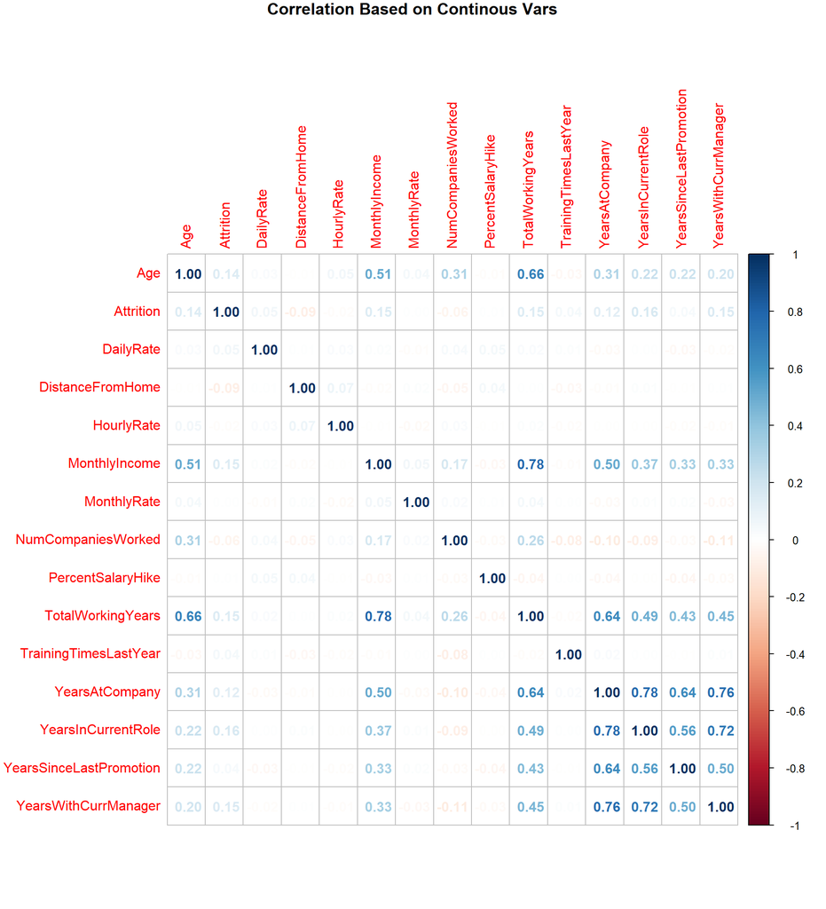

```r
# Remove columns that do not provide significance
emp_data_mod <- emp_data[-c(1, 10, 11, 23, 28)]

# Create New data frame for continous data
emp_data_mod_cont <- subset(emp_data_mod, select = c(Age, Attrition, DailyRate, DistanceFromHome,
                                           HourlyRate,MonthlyIncome, MonthlyRate, NumCompaniesWorked,
                                           PercentSalaryHike, TotalWorkingYears, TrainingTimesLastYear,
                                           YearsAtCompany, YearsInCurrentRole, YearsSinceLastPromotion,
                                           YearsWithCurrManager))

# Make attrition logical in emp_data_mod_cat
emp_data_mod_cont$Attrition <- replace(emp_data_mod_cont$Attrition,
                                      emp_data_mod_cont$Attrition=="No", as.numeric(1))
emp_data_mod_cont$Attrition <- replace(emp_data_mod_cont$Attrition,
                                      emp_data_mod_cont$Attrition=="Yes", as.numeric(0))

# Normalize
emp_data_mod_cont <- as.data.frame(lapply(emp_data_mod_cont, as.numeric))
emp_data_mod_cont <- as.data.frame(lapply(emp_data_mod_cont, min_max_norm))

# Create correlation plot
emp_data_mod_cont_cor <- cor(emp_data_mod_cont)
corrplot(emp_data_mod_cont_cor, method='number', title='Correlation Based on Continous Vars',
         mar=c(0,0,1,0))
```

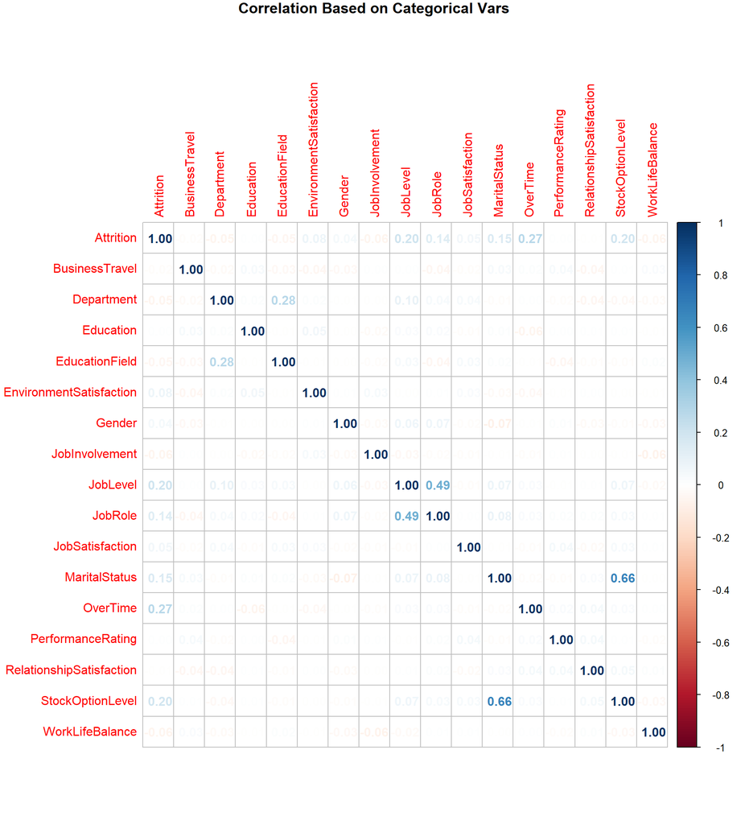

```r
# Create data frame for categorical data "Including Attrition"
emp_data_mod_cat <- subset(emp_data_mod, select=c(Attrition, BusinessTravel, Department, Education,
                                                  EducationField, EnvironmentSatisfaction, Gender,
                                                  JobInvolvement, JobLevel, JobRole, JobSatisfaction,
                                                  MaritalStatus, OverTime, PerformanceRating,
                                                  RelationshipSatisfaction, StockOptionLevel,
                                                  WorkLifeBalance))
# Transform with function
emp_data_mod_cat <- CategoryToPercent(emp_data_mod_cat)

# Set attrition to 1 and 0
emp_data_mod_cat$Attrition <- replace(emp_data_mod_cat$Attrition,
                                      emp_data_mod_cat$Attrition=="No", as.numeric(0))
emp_data_mod_cat$Attrition <- replace(emp_data_mod_cat$Attrition,
                                      emp_data_mod_cat$Attrition=="Yes", as.numeric(1))
# Set columns to numeric if they arne't
emp_data_mod_cat <- as.data.frame(lapply(emp_data_mod_cat, as.numeric))
emp_data_mod_cat <- as.data.frame(lapply(emp_data_mod_cat, InvertPercentage))

# Create Correlation for categorical
emp_data_mod_cat_cor <- cor(emp_data_mod_cat)
corrplot(emp_data_mod_cat_cor, method='number', title='Correlation Based on Categorical Vars',
         mar=c(0,0,1,0))
```

## Correlation Notes

### Categories that make the biggest difference

- Age, MonthlyIncome, TotalWorkingYears, YearsAtCompany, YearsInCurrentRole,  
  YearsWithCurrManager, JobLevel, JobRole, MaritalStatus, OverTime, StockOptionLevel

### Categories that make the least difference

- HourlyRate, MonthlyRate, PercentSalaryHike, Education, PerformanceRating,  
  RelationshipSatisfaction

## Top Contendors for Attrition

- JobLevel
- OverTime
- StockOptionLevel Since Changing Stock Options can be very expensive the 3rd place could be  
  “YearsInCurrentRole”

# Testing KNN Models with different

```r
set.seed(3)
# Standardize the data the same way using a reusable data prep function I wrote
# All prep work is done in this function
knn_emp_data <- PrepareData(emp_data)

# Create empty train and test data frames
knn_emp_data_train <- data.frame()
knn_emp_data_test <- data.frame()

# Split Data 70/30
num_samples_to_take <- round(as.numeric(nrow(knn_emp_data)*.7), digits=0)
index <- sample(seq_len(nrow(knn_emp_data)), size=num_samples_to_take)
knn_emp_data_train <- knn_emp_data[index,]
knn_emp_data_test <- knn_emp_data[-index,]

############################ KNN Model ########################################
# Formula for Nearest_Neighbor
knn_emp_formula <- as.formula(Attrition ~ Age + BusinessTravel + DailyRate + Department +
  DistanceFromHome + EducationField + EnvironmentSatisfaction + Gender +
  JobInvolvement + JobLevel + JobRole + JobSatisfaction + MaritalStatus +
  MonthlyIncome + NumCompaniesWorked + OverTime + StockOptionLevel + TotalWorkingYears +
  TrainingTimesLastYear + WorkLifeBalance + YearsAtCompany + YearsInCurrentRole +
  YearsSinceLastPromotion + YearsWithCurrManager)

# Define K values
optimal_k <- 3

# Generate Model
attrition_model_2 <- nearest_neighbor(neighbors=optimal_k, weight_func="inv") %>%
  set_engine("kknn") %>%
  set_mode("classification") %>%
  fit(formula=knn_emp_formula, data=knn_emp_data_train)

# Create prediction
pred_grid <- attrition_model_2 %>% predict(knn_emp_data_test)
attrition_tab_2 <- table(pred_grid$.pred_class, knn_emp_data_test$Attrition)
confusionMatrix(attrition_tab_2)
```

```
## Confusion Matrix and Statistics
##
##
##        No Yes
##   No  288  37
##   Yes  10  16
##
##                Accuracy : 0.8661
##                  95% CI : (0.8259, 0.8999)
##     No Information Rate : 0.849
##     P-Value [Acc > NIR] : 0.2077365
##
##                   Kappa : 0.3394
##
##  Mcnemar's Test P-Value : 0.0001491
##
##             Sensitivity : 0.9664
##             Specificity : 0.3019
##          Pos Pred Value : 0.8862
##          Neg Pred Value : 0.6154
##              Prevalence : 0.8490
##          Detection Rate : 0.8205
##    Detection Prevalence : 0.9259
##       Balanced Accuracy : 0.6342
##
##        'Positive' Class : No
##
```

```r
#################################################################################
```

- With many attempts at changing the k value and the formula, the best results  
  I could acheive is with a 96%-Sensitivity and 30%-Specificity

# Random Forest

```r
set.seed(4)

# Use random forest to give us a different model to compare to
# rf = Random Forest
rf_emp_data <- emp_data

# Convert the categorical values to numbers as factors
rf_emp_data <- ConvertCatToNum(rf_emp_data)
# Prepare data to keep it standardized
rf_emp_data <- PrepareData(rf_emp_data)

# Create empty train and test data frames
rf_emp_data_train <- data.frame()
rf_emp_data_test <- data.frame()

# Split Data 70/30
num_samples_to_take <- round(as.numeric(nrow(rf_emp_data)*.7), digits=0)
index <- sample(seq_len(nrow(rf_emp_data)), size=num_samples_to_take)
rf_emp_data_train <- rf_emp_data[index,]
rf_emp_data_test <- rf_emp_data[-index,]

# Train Random Forest Model
rf_model <- randomForest(
  Attrition ~ .,
  data=rf_emp_data_train
)
# Print Model details
rf_model
```

```
##
## Call:
##  randomForest(formula = Attrition ~ ., data = rf_emp_data_train)
##                Type of random forest: classification
##                      Number of trees: 500
## No. of variables tried at each split: 5
##
##         OOB estimate of  error rate: 13.92%
## Confusion matrix:
##     0  1 class.error
## 0 691  6 0.008608321
## 1 108 14 0.885245902
```

```r
# Predict
rf_predict <- predict(rf_model, newdata=rf_emp_data_test)
rf_predict <- as.data.frame(rf_predict)

# Create table for confusion Matrix
rf_cm <- table(rf_emp_data_test$Attrition, rf_predict$rf_predict)
confusionMatrix(rf_cm)
```

```
## Confusion Matrix and Statistics
##
##
##       0   1
##   0 278   4
##   1  54  15
##
##                Accuracy : 0.8348
##                  95% CI : (0.7917, 0.8721)
##     No Information Rate : 0.9459
##     P-Value [Acc > NIR] : 1
##
##                   Kappa : 0.2798
##
##  Mcnemar's Test P-Value : 1.243e-10
##
##             Sensitivity : 0.8373
##             Specificity : 0.7895
##          Pos Pred Value : 0.9858
##          Neg Pred Value : 0.2174
##              Prevalence : 0.9459
##          Detection Rate : 0.7920
##    Detection Prevalence : 0.8034
##       Balanced Accuracy : 0.8134
##
##        'Positive' Class : 0
##
```

# Predict Attrition

```r
# Use the best model (Random Forest) to predict attrition from the provided data
# Create output CSV of the results
emp_final_pred <- comp_set_no_attrition

# Like the training data, run the data through the same prep functions
# Convert the categorical values to numbers as factors
emp_final_pred <- ConvertCatToNum(emp_final_pred)
# Prepare data to keep it standardized
emp_final_pred <- PrepareData(emp_final_pred)

# Prediction Time
rf_final_pred <- predict(rf_model, newdata=emp_final_pred)
rf_predict <- as.data.frame(rf_final_pred)

# Replace 0's and 1's with no and yes
rf_predict <- transform(rf_predict, rf_final_pred=as.character(rf_final_pred))
rf_predict$rf_final_pred[rf_predict$rf_final_pred=="0"] <- "No"
rf_predict$rf_final_pred[rf_predict$rf_final_pred=="1"] <- "Yes"

# Change Column name
colnames(rf_predict) <- c("Attrition")
count(rf_predict)
```

```
##   Attrition freq
## 1        No  296
## 2       Yes    4
```

```r
# Add back to data
rf_predict$ID <- comp_set_no_attrition$ID
comp_set_predicted_attrition <- merge(comp_set_no_attrition, rf_predict, by="ID")

# Create DF of employees that predicted yes for attrition
positive_attrition <- filter(comp_set_predicted_attrition,
                               comp_set_predicted_attrition$Attrition=="Yes")

positive_attrition
```

```
##     ID Age BusinessTravel DailyRate             Department DistanceFromHome
## 1 1205  21  Travel_Rarely      1334 Research & Development               10
## 2 1233  20  Travel_Rarely      1097 Research & Development               11
## 3 1421  33  Travel_Rarely      1017 Research & Development               25
## 4 1439  39     Non-Travel       592 Research & Development                2
##   Education EducationField EmployeeCount EmployeeNumber EnvironmentSatisfaction
## 1         3  Life Sciences             1           1079                       3
## 2         3        Medical             1           1016                       4
## 3         3        Medical             1           1108                       1
## 4         3  Life Sciences             1           1458                       1
##   Gender HourlyRate JobInvolvement JobLevel               JobRole
## 1 Female         36              2        1 Laboratory Technician
## 2 Female         98              2        1    Research Scientist
## 3   Male         55              2        1    Research Scientist
## 4 Female         54              2        1 Laboratory Technician
```

[output cut: 25 more lines]